# CXR in COVID Analysis

Dr Aditya Borakati

Royal Free Hospital, London, UK  
a.borakati@doctors.org.uk

10/06/2020

## Software Environment and Packages

```r
R version 4.0.0 (2020-04-24)
Platform: x86_64-w64-mingw32/x64 (64-bit)
Running under: Windows 10 x64 (build 19041)
Matrix products: default
locale:
LC_COLLATE=English_United Kingdom.1252  LC_CTYPE=English_United Kingdom.1252
LC_MONETARY=English_United Kingdom.1252 LC_NUMERIC=C
LC_TIME=English_United Kingdom.1252
attached base packages:
stats     graphics  grDevices utils     datasets  methods   base
other attached packages:
corrplot 0.84
  Taiyun Wei and Viliam Simko (2017). R package "corrplot": Visualization of
  a Correlation Matrix (Version 0.84). Available from
  https://github.com/taiyun/corrplot
MKmisc 1.6
  Kohl M (2019). MKmisc: Miscellaneous functions from M. Kohl_. R package version 1.6, http://www.stamats.de
epiR 1.0-14
  Mark Stevenson with contributions from Telmo Nunes, Cord Heuer, Jonathon
  Marshall, Javier Sanchez, Ron Thornton, Jeno Reiczigel, Jim Robison-Cox,
  Paola Sebastiani, Peter Solymos, Kazuki Yoshida, Geoff Jones, Sarah
  Pirikahu, Simon Firestone, Ryan Kyle, Johann Popp, Mathew Jay and Charles
  Reynard. (2020). epiR: Tools for the Analysis of Epidemiological Data. R
  package version 1.0-14. https://CRAN.R-project.org/package=epiR
Matching 4.9-7
  Jasjeet S. Sekhon (2011). Multivariate and Propensity Score Matching
  Software with Automated Balance Optimization: The Matching Package for R.
  Journal of Statistical Software, 42(7), 1-52. URL http://www.jstatsoft.org/v42/i07/.
MASS 7.3-51.5
  Venables, W. N. & Ripley, B. D. (2002) Modern Applied Statistics with S.
  Fourth Edition. Springer, New York. ISBN 0-387-95457-0
Ordinal 2019.12-10
  Christensen, R. H. B. (2019). ordinal - Regression Models for Ordinal Data. R package version    2019.12-10. https://CRAN.R-project.org/package=ordinal.
Hmisc 4.4-0
  Frank E Harrell Jr, with contributions from Charles Dupont and many
  others. (2020). Hmisc: Harrell Miscellaneous. R package version 4.4-0.
  https://CRAN.R-project.org/package=Hmisc
Formula 1.2-3
  Achim Zeileis, Yves Croissant (2010). Extended Model Formulas in R:
  Multiple Parts and Multiple Responses. Journal of Statistical Software
  34(1), 1-13. doi:10.18637/jss.v034.i01
lattice 0.20-41
  Sarkar, Deepayan (2008) Lattice: Multivariate Data Visualization with R.
  Springer, New York. ISBN 978-0-387-75968-5
mice 3.8.0
  Stef van Buuren, Karin Groothuis-Oudshoorn (2011). mice: Multivariate
  Imputation by Chained Equations in R. Journal of Statistical Software,
  45(3), 1-67. URL https://www.jstatsoft.org/v45/i03/.
readxl 1.3.1
  Hadley Wickham and Jennifer Bryan (2019). readxl: Read Excel Files. R
  package version 1.3.1. https://CRAN.R-project.org/package=readxl
finalfit 1.0.1
  Ewen Harrison, Tom Drake and Riinu Ots (2020). finalfit: Quickly Create
  Elegant Regression Results Tables and Plots when Modelling. R package
  version 1.0.1. https://CRAN.R-project.org/package=finalfit
MatchIt 3.0.2
  Daniel E. Ho, Kosuke Imai, Gary King, Elizabeth A. Stuart (2011). MatchIt:
  Nonparametric Preprocessing for Parametric Causal Inference. Journal of
  Statistical Software, Vol. 42, No. 8, pp. 1-28. URL
  http://www.jstatsoft.org/v42/i08/
tableone 0.11.1
  Kazuki Yoshida (2020). tableone: Create 'Table 1' to Describe Baseline
  Characteristics. R package version 0.11.1.
  https://CRAN.R-project.org/package=tableone
forcats 0.5.0
  Hadley Wickham (2020). forcats: Tools for Working with Categorical
  Variables (Factors). R package version 0.5.0.
  https://CRAN.R-project.org/package=forcats
stringr 1.4.0
  Hadley Wickham (2019). stringr: Simple, Consistent Wrappers for Common
  String Operations. R package version 1.4.0.
  https://CRAN.R-project.org/package=stringr
dplyr 0.8.5
  Hadley Wickham, Romain François, Lionel Henry and Kirill Müller (2020).
  dplyr: A Grammar of Data Manipulation. R package version 0.8.5.
  https://CRAN.R-project.org/package=dplyr
purrr 0.3.4
  Lionel Henry and Hadley Wickham (2020). purrr: Functional Programming
  Tools. R package version 0.3.4. https://CRAN.R-project.org/package=purrr
readr 1.3.1
  Hadley Wickham, Jim Hester and Romain Francois (2018). readr: Read
  Rectangular Text Data. R package version 1.3.1.
  https://CRAN.R-project.org/package=readr
tidyr 1.0.2
  Hadley Wickham and Lionel Henry (2020). tidyr: Tidy Messy Data. R package
  version 1.0.2. https://CRAN.R-project.org/package=tidyr
tibble 3.0.0
  Hadley Wickham and Lionel Henry (2020). tidyr: Tidy Messy Data. R package
  version 1.0.2. https://CRAN.R-project.org/package=tidyr
ggplot2 3.3.0
  H. Wickham. ggplot2: Elegant Graphics for Data Analysis. Springer-Verlag
  New York, 2016.
tidyverse 1.3.0
  Wickham et al., (2019). Welcome to the tidyverse. Journal of Open Source
  Software, 4(43), 1686, https://doi.org/10.21105/joss.01686
forestplot 1.9
  Max Gordon and Thomas Lumley (2019). forestplot: Advanced Forest Plot Using 'grid' Graphics. R package version 1.9.   https://CRAN.R-project.org/package=forestplot
MatchThem 0.9.3
  Farhad Pishgar and Noah Greifer (2020). MatchThem: Matching and Weighting Multiply Imputed Datasets. R package version 0.9.3. https://CRAN.R-project.org/package=MatchThem
miceadds 3.9-14
 Robitzsch, A., & Grund, S. (2020). miceadds: Some Additional Multiple Imputation Functions, Especially for 'mice'. R package version 3.9-14. https://CRAN.R-project.org/package=miceadds
cobalt 4.2.2
 Noah Greifer (2020). cobalt: Covariate Balance Tables and Plots. R package version 4.2.2.   https://CRAN.R-project.org/package=cobalt
```

## Load Packages and Data

### Load Packages:

```r
library(MKmisc)
library(tidyverse)
library(tableone)
library(MatchIt)
library(finalfit)
library(readxl)
library(cobalt)
library(mice)
library(miceadds)
library(Hmisc)
library(epiR)
library(MatchThem)
library(ordinal)
library(forestplot)
```

## Power Calculation

```r
power.diagnostic.test(sens = 0.56,
                      sig.level = 0.05,
                      delta = 0.1,
                      power = 0.8) %>% print()->power
```

```r
 Diagnostic test exact power calculation

           sens = 0.56
              n = 165
             n1 = 165
          delta = 0.1
      sig.level = 0.05
          power = 0.8
           prev = NULL

NOTE: n is number of cases, n1 is number of controls
```

## Load Data:

```r
data <- read_csv(
  "FullDataWithCT.csv",
  col_types = cols(
    Age = col_integer(),
    Albumin = col_number(),
    CK = col_number(),
    CT = col_character(),
    CRP = col_number(),
    DDimer = col_number(),
    DateOfDeath = col_date(format = "%d/%m/%Y"),
    DateOfDischarge = col_date(format = "%d/%m/%Y"),
    DateOfVisit = col_date(format = "%d/%m/%Y"),
    DateOfSymptomOnset = col_date(format = "%d/%m/%Y"),
    DiastolicBP = col_number(),
    FiO2 = col_skip(),
    GCS = col_number(),
    HR = col_number(),
    MRN = col_skip(),
    NEWS = col_number(),
    'NEWS2(noFiO2)' = col_skip(),
    Neutrophils = col_number(),
    RR = col_number(),
    Sats = col_number(),
    'Supplemental Oxygen' = col_skip(),
    SystolicBP = col_number(),
    Temperature = col_number(),
    Troponin = col_number(),
    CTBSTI = col_integer()
  )
)
```

## Data Cleaning

###### Format data into factors/ differences between dates:

```r
data <- mutate_if(data, is.character, as.factor)
data$DayOfSymptoms <-
  difftime(data$DateOfVisit, data$DateOfSymptomOnset, units = "days")
data$TimeToDeath <-
  abs(difftime(data$DateOfDeath, data$DateOfVisit, units = "days"))
data$DayOfSymptoms <- as.numeric(data$DayOfSymptoms)
data$TimeToDeath <- as.numeric(data$TimeToDeath)
```

#### Recode ethnicities as too many options:

###### This code collapses the ethnicity categories into ‘White’, ‘Black’, ‘South Asian’, ‘Other Asian’, ‘Mixed’ or ‘Other’;

```r
fct_collapse(
  data$Ethnicity,
  White = c(
    "White - British",
    "White - Irish",
    "White - Any Other White Background"
  )
) -> data$Ethnicity
fct_collapse(
  data$Ethnicity,
  Black = c(
    "Black - Any Other Black Background",
    "Black or Black British - A0rican",
    "Black or Black British - African",
    "Black or Black British - Caribbean"
  )
) -> data$Ethnicity
fct_collapse(
  data$Ethnicity,
  'South Asian' = c(
    "Asian or Asian British - Bangladeshi",
    "Asian or Asian British - Indian",
    "Asian or Asian British - Pakistani"
  )
) -> data$Ethnicity
fct_collapse(data$Ethnicity,
             'Other Asian' = c("Asian - Any Other Asian Background",
                               "Other - Chinese")) -> data$Ethnicity
fct_collapse(
  data$Ethnicity,
  'Mixed' = c(
    "mixed - Any Other mixed Background",
    "Mixed - Any Other Mixed Background",
    "Mixed - White and Asian",
    "Mixed - White and Black African",
    "mixed - White and Black Caribbean",
    "Mixed - White and Black Caribbean"
  )
) -> data$Ethnicity
```

###### New XR positive column for “Classic Covid” or not:

```r
data$XRPositive <-
  ifelse(data$XRChest == "Classic COVID", "Positive", "Negative")
data$XRPositive <- as.factor(data$XRPositive)
```

### Follow Up Swabs + Initial Swabs Positive:

###### Creates new column ‘OverallPos’ which includes initial RT-PCR swab and follow-up swabs in 30 days of attendance, if any are positive the value will be positive in this column

```r
data$OverallPos<-case_when(data$RTPCR == "Positive" | data$FollowUpPos == "Positive"~"Positive")
replace_na(data$OverallPos,"Negative")->data$OverallPos
```

###### Create new vector with all variable names (i.e. the column headers)

```r
explanatory <- names(data)
```

### Paired XR and RT-PCR data

#### Creates new variable ‘completedata’ which contains only patients who had both CXR and RT-PCR in ED

```r
completedata <- filter(data, !is.na(data$XRPositive) & !is.na(data$RTPCR))
```

##### Remove missing data variable

```r
completedata <- completedata[-c(31)]
```

#### Format complete data variables

```r
completedata$OverallPos <- as.factor(completedata$OverallPos)

completedata$ThirtyDayFU<-as.factor(completedata$ThirtyDayFU)
completedata$TimeToDeath <-
  abs(difftime(completedata$DateOfDeath,
               completedata$DateOfVisit, units = "days"))

completedata$TimeToDeath <- as.numeric(completedata$TimeToDeath)
```

###### Set ‘XRChest’ as ordinal variable on scale of ‘Alternative pathology’ as lowest value and ‘Classical COVID’ as highest

```r
completedata$XRChest <- ordered(
  completedata$XRChest,
  levels = c(
    "Alternative pathology",
    "No abnormalities",
    "Indeterminate",
    "Classic COVID"
  )
)
```

###### Convert CT BSTI grade column into factor:

```r
completedata$CTBSTI<-as.factor(completedata$CTBSTI)
```

## Demographic table of raw data

###### This code creates an unformatted demographic table (table 2 in manuscript), for the raw data, stratified by RT-PCR status, significance testing between RT-PCR +ve and -ve groups is carried out automatically using chi squared, t-tests, ANOVA etc.; there is also a column for the proportion of missing data

```
CreateTableOne(vars = explanatory,
               strata = 'OverallPos',
               data = completedata) -> demogtable

#### List nonnormal factors for summarisation as median / IQR and non parametric statistical test

explanatorynnormal<-c("Sats","RR", "GCS", "SystolicBP", "Temperature", "HR", "Neutrophils",
+                       "DDimer","Albumin","CRP","CK","Troponin")
as.data.frame(print(demogtable, nonnormal = explanatorynnormal, missing = TRUE))->demogtable

write.csv(demogtable, file = "Demogtable.csv")
```

```
  Age (mean (SD))                     62.74 (17.72)             66.18 (17.58)            0.001
  Ethnicity (%)                                                                          0.097
     Other Asian                         29 ( 8.0)                 72 ( 11.8)
     South Asian                         27 ( 7.5)                 38 (  6.2)
     Black                               41 (11.4)                 91 ( 14.9)
     Mixed                                6 ( 1.7)                  6 (  1.0)
     Other - Any Other Ethnic Group      56 (15.5)                105 ( 17.2)
     White                              202 (56.0)                297 ( 48.8)
  Sex = Male (%)                        233 (53.6)                480 ( 62.9)            0.002
  Sats (median [IQR])                 95.00 [92.00, 98.00]      93.00 [88.00, 96.00]    <0.001 nonnorm
  RR (median [IQR])                   22.00 [20.00, 28.00]      26.00 [20.00, 32.00]    <0.001 nonnorm
  GCS (median [IQR])                  15.00 [15.00, 15.00]      15.00 [15.00, 15.00]     0.043 nonnorm
  SystolicBP (median [IQR])          134.00 [119.00, 151.50]   130.00 [115.00, 145.00]   0.009 nonnorm
  DiastolicBP (mean (SD))             79.54 (16.40)             75.61 (14.51)           <0.001
  HR (median [IQR])                   96.00 [83.00, 110.00]     94.00 [81.00, 108.00]    0.092 nonnorm
  Temperature (median [IQR])          37.10 [36.60, 38.00]      37.70 [37.00, 38.40]    <0.001 nonnorm
  XRChest (%)                                                                           <0.001
     Alternative pathology                4 ( 0.9)                  3 (  0.4)
     No abnormalities                   178 (40.9)                136 ( 17.8)
     Indeterminate                       83 (19.1)                169 ( 22.1)
     Classic COVID                      170 (39.1)                455 ( 59.6)
  CTPA = PE (%)                          16 (30.2)                 28 ( 45.9)            0.127
  Comorbidity = Yes (%)                 297 (79.0)                482 ( 80.3)            0.669
  Dyspnoea = Yes (%)                    274 (69.4)                497 ( 75.5)            0.034
  Neutrophils (median [IQR])           6.42 [4.55, 9.11]         5.25 [3.69, 7.61]      <0.001 nonnorm
  DDimer (median [IQR])             1250.00 [619.00, 3059.00] 1105.00 [626.00, 2428.50]  0.204 nonnorm
  Albumin (median [IQR])              39.00 [35.00, 42.00]      37.00 [34.00, 40.00]    <0.001 nonnorm
  CRP (median [IQR])                  51.00 [13.00, 117.00]     83.00 [42.00, 158.00]   <0.001 nonnorm
  CK (median [IQR])                   91.00 [54.00, 169.00]    146.50 [78.00, 342.75]   <0.001 nonnorm
  Troponin (median [IQR])             19.00 [7.00, 53.00]       20.00 [9.00, 53.00]      0.278 nonnorm
  Admitted = Discharged (%)             104 (24.0)                128 ( 16.8)            0.003
  AdmittedToITU = Yes (%)                 5 ( 1.3)                 32 (  4.8)            0.005
  RTPCR = Positive (%)                    0 ( 0.0)                738 ( 96.7)           <0.001
  CT = 1 (%)                             37 (57.8)                 26 ( 86.7)            0.011
  NEWS (mean (SD))                     4.36 (3.06)               5.48 (2.71)             0.032
  ThirtyDayFU (%)                                                                       <0.001
     1                                  219 (78.2)                367 ( 58.3)
     2                                   14 ( 5.0)                 49 (  7.8)
     3                                   18 ( 6.4)                 60 (  9.5)
     4                                   29 (10.4)                154 ( 24.4)
  CTBSTI (%)                                                                            <0.001
     0                                   23 (22.1)                  6 (  3.3)
     1                                   52 (50.0)                157 ( 85.8)
     2                                   14 (13.5)                 14 (  7.7)
     3                                   15 (14.4)                  6 (  3.3)
  DayOfSymptoms (mean (SD))            9.84 (9.63)               8.56 (15.80)            0.368
  TimeToDeath (mean (SD))             50.33 (77.93)             57.76 (70.02)            0.618
  XRPositive = Positive (%)             170 (39.1)                455 ( 59.6)           <0.001
  OverallPos = Positive (%)               0 ( 0.0)                763 (100.0)
```

###### Limited dataset comprising relevant data and those without significant missingness:

```r
limcompletedata <- dplyr::select(completedata,
                                 c("Age",
                                   "XRChest",
                                   "Ethnicity",
                                   "Sex",
                                   "RR",
                                   "Sats",
                                   "GCS",
                                   "Temperature",
                                   "HR",
                                   "SystolicBP",
                                   "DiastolicBP",
                                   "Neutrophils",
                                   "DDimer",
                                   "CRP",
                                   "Troponin",
                                   "Albumin",
                                   "CK",
                                   "OverallPos",
                                   "Admitted",
                                   "AdmittedToITU",
                                   "ThirtyDayFU",
                                   "Dyspnoea",
                                   "Comorbidity",
                                   "XRPositive"))
```

## Imputation

###### This code generates 15 imputed datasets using the permuted mean matching method, based on the ‘limcompletedata’ dataset which has filtered the most relevant fields, with minimal missing data initially

```r
imputed <- mice(limcompletedata, m = 15, method = 'pmm')
```

###### Imputation Diagnostics Density plot, this corresponds to supplementary figure 1:

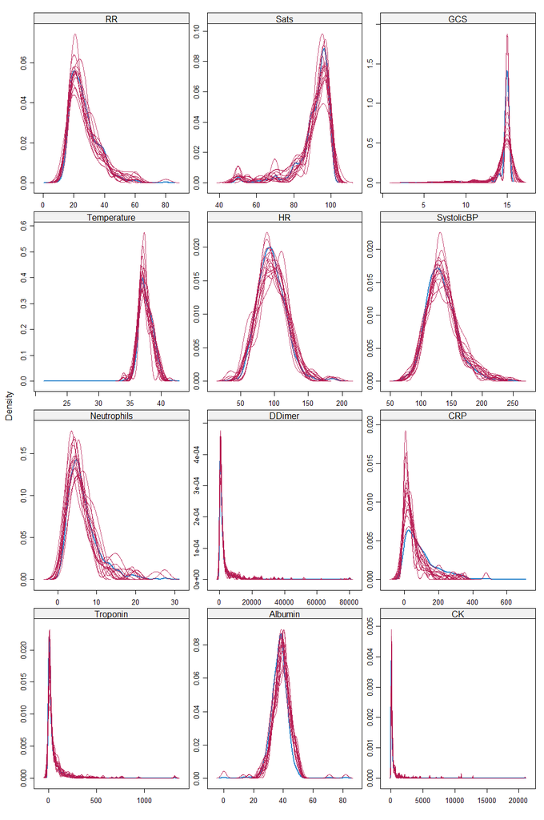

```r
densityplot(imputed)
```

## Propensity Score Matching

###### This code matches data in the imputed datasets on whether the XR was reported classical COVID or not, the matching is done based on the covariates Sex, Age, Comorbidity, Ethnicity and Respiratory Rate

```r
library(MatchThem)
#### MatchThem package requires dependent variable to be coded as 0 or 1
imputed[["data"]][["XRPositive"]] %>% recode_factor("Positive" = "1", "Negative" = "0") ->imputed[["data"]][["XRPositive"]]
matchthem(
  XRPositive ~ Sex + Age + Comorbidity + Ethnicity + RR,
  data = imputed,
  method = 'nearest',
  verbose = FALSE,
  replace = FALSE,
  ratio = 1,
  caliper = 0.2,
  m.order = "random",) -> matchedtest
### Set XRChest to unordered for binomial analyses
matchedtest[["datasets"]]c(1:15)[["XRChest"]] %>% factor(ordered = FALSE) -> matched2[["datasets"]]c(1:15)[["XRChest"]]
```

### Match Balance Diagnostics

##### Creates plots and table with mean difference and distributation of values in covariates betweeen XR +ve and -ve groups after matching across all imputed datasets:

```r
#### Supplementary tables 1,2 and 3:
bal.tab(matchedtest)
#### Supplementary figure 2
bal.plot(matchedtest)
#### Supplementary figure 3:
bal.plot(matchedtest, var.name = "Age", type = "histogram", which = "both")
bal.plot(matchedtest, var.name = "Sex", type = "histogram", which = "both")
bal.plot(matchedtest, var.name = "Ethnicity", type = "histogram", which = "both")
bal.plot(matchedtest, var.name = "RR", type = "histogram", which = "both")
bal.plot(matchedtest, var.name = "Comorbidity", type = "histogram", which = "both")
#### Supplementary figure 4:
love.plot(matchedtest)
```

#### Matched Demographics Table:

###### Stack matched imputed datasets into one large datset and split into COVID +ve and -ve groups:

```r
### 'all=FALSE' gets matched data only
stacked<-MatchThem::complete(matchedtest, n = c(1:15), all = FALSE)
stacked<-stacked %>% filter(.imp>0)
```

###### Creates demographics table as above, but on propensity matched imputed datasets, corresponds to Table 4:

```r
CreateTableOne(strata = "OverallPos", data = stacked)-> table4
#### Means and SD kept as is, mean counts calculated after dividing by 15 (as 15 imputed datasets)
```

###### Creates demographic table stratified by XR Positive or Negative on matched imputed datasets, correpsonds to Table 5:

```r
CreateTableOne(strata = "XRPositive", data = stacked)-> table5
#### Means and SD kept as is, mean counts calculated after dividing by 15 (as 15 imputed datasets)
```

###### Summary statistics for pooled data:

```r
### Normal means sd
explanatorynorm<-c("Age","Temperature","HR","SystolicBP")
stacked %>% group_by(OverallPos) %>%
  summarise_at(vars(explanatorynorm),list(mean.default, sd))->summarynormalOverallPos
stacked %>% group_by(XRPositive) %>%
  summarise_at(vars(explanatorynorm),list(mean.default, sd))->summarynormalXRPositive

### Non normal medians and IQR
stacked %>% group_by(OverallPos) %>%
  summarise_at(vars(explanatorynnormal),list(median, IQR))->summarynnormalOverallPos
stacked %>% group_by(XRPositive) %>%
  summarise_at(vars(explanatorynnormal),list(median, IQR))->summarynnormalXRPositive
```

## Diagnostic Accuracy

#### This section generates the diagnostic accuracy statistics (e.g. sensitivity, specificity) for CXR and CT with RT-PCR as the reference standard using the matched imputed datasets

#### This code creates a contingency table of False/ True Positives and Negatives for Chest X-ray taken from the demographic tables above:

```r
contingxr <-
  matrix(c(305,243,125,187),
         nrow = 2,
         ncol = 2)

colnames(contingxr) <- c("PCR+", "PCR-")

rownames(contingxr) <- c("XR+", "XR-")
```

##### This function calculates diagnostic accuracy test statistics:

```r
epi.tests(contingxr, conf.level = 0.95) -> xraccuracy
```

#### Giving the diagnostic accuracy output for CXR in table 3:

````r
xraccuracy
          Outcome +    Outcome -      Total
Test +          305          125        430
Test -          243          187        430
Total           548          312        860

Point estimates and 95 % CIs:
---------------------------------------------------------
Apparent prevalence                    0.50 (0.47, 0.53)
True prevalence                        0.64 (0.60, 0.67)
Sensitivity                            0.56 (0.51, 0.60)
Specificity                            0.60 (0.54, 0.65)
Positive predictive value              0.71 (0.66, 0.75)
Negative predictive value              0.43 (0.39, 0.48)
Positive likelihood ratio              1.39 (1.19, 1.62)
Negative likelihood ratio              0.74 (0.65, 0.84)
---------------------------------------------------------```
````

###### NB diagnostic accuracy values in table available in list view of xraccuracy variable

## CT Data and Accuracy

###### Only those with CT and RT PCR:

```r
CTdata <-
  filter(data, is.na(data$CTBSTI) == FALSE &
           is.na(data$RTPCR) == FALSE)
```

###### Select relevant variables

```r
CTdata <-
  dplyr::select(CTdata, c("Age",
                          "XRChest",
                          "Ethnicity",
                          "Sex",
                          "RR",
                          "Sats",
                          "GCS",
                          "Temperature",
                          "HR",
                          "SystolicBP",
                          "DiastolicBP",
                          "Neutrophils",
                          "DDimer",
                          "CRP",
                          "Troponin",
                          "OverallPos",
                          "Admitted",
                          "AdmittedToITU",
                          "ThirtyDayFU",
                          "Dyspnoea",
                          "Comorbidity",
                          "XRPositive",
                          "OverallPos",
                          "CTBSTI"))
```

###### Set RT-PCR as factor:

```r
CTdata$OverallPos<-as.factor(CTdata$OverallPos)
```

###### Rename 1 and 0 to Positive and Negative:

```r
CTdata$CTPositive <-
  ifelse(CTdata$CTBSTI == "1", "Positive", "Negative")
CTdata$CTPositive <- as.factor(CTdata$CTPositive)
```

###### Regression with CT as outcome variable:

```r
CT <- finalfit(
  CTdata,
  "OverallPos",
  c(
    "Age",
    "Sex",
    "RR",
    "GCS",
    "CTPositive",
    "Temperature",
    "HR",
    "SystolicBP",
    "DiastolicBP",
    "Sats",
    "Dyspnoea",
    "Comorbidity"

  ),
  confint_level = 0.95
)
```

###### Contingency table of True/False Positives and Negatives for CT taken from Regression table:

```r
contingct <-
  matrix(c(CT[7,4], CT[6,4], CT[7,3], CT[6,3]),
         nrow = 2,
         ncol = 2)
colnames(contingct) <- c("PCR+", "PCR-")
rownames(contingct) <- c("CT+", "CT-")
substr(contingct, start = 1, stop = 3)->contingct
sapply(contingct,as.numeric)->contingct
matrix(contingct, nrow = 2, ncol = 2)->contingct
colnames(contingct) <- c("PCR+", "PCR-")

rownames(contingct) <- c("CT+", "CT-")
```

###### Diagnostic accuracy statistics for CT

```r
epi.tests(contingct, conf.level = 0.95) -> ctaccuracy
          Outcome +    Outcome -      Total
Test +          162           55        217
Test -           29           56         85
Total           191          111        302

Point estimates and 95 % CIs:
---------------------------------------------------------
Apparent prevalence                    0.72 (0.66, 0.77)
True prevalence                        0.63 (0.58, 0.69)
Sensitivity                            0.85 (0.79, 0.90)
Specificity                            0.50 (0.41, 0.60)
Positive predictive value              0.75 (0.68, 0.80)
Negative predictive value              0.66 (0.55, 0.76)
Positive likelihood ratio              1.71 (1.41, 2.08)
Negative likelihood ratio              0.30 (0.21, 0.44)
---------------------------------------------------------
```

###### NB Diagnostic accuracy values found in list view rather than output

## CT and XR accuracy comparison

#### In this section mean differences of diagnostic accuracy statistics between CT and Chest X-ray with confidence intervals and p-values are calculated